# Metodología

En la literatura suele referirse a los prepagos mediante un indicador denominado Conditional Prepayment Rate (${CPR}_t$) que surge de anualizar la tasa de prepago observada en el mes $t$, denominada Single Monthly Mortality Rate (${SMM}_t$):
$${SMM}_t = \frac{\sum^{n}_{i=1}{Prepago}_{it}}{\sum^{n}_{i=1}{({Saldo}_{it} - {Amortización}_{it})}}$$
donde $n$ representa el número de préstamos vigentes en el mes $t$, ${Prepago}_{it}$ el monto pre-pagado (total o parcial) por cada crédito, ${Saldo}_{it}$ saldo de deuda al inicio del mes y ${Amortización}_{it}$ la amortización programada dicho período. La anualización de la SMM se obtiene de la siguiente expresión:
$${CPR}_t = 1 - (1-{SMM}_t)^{12}$$
Las series históricas de prepagos, pueden ser explicadas también por factores exógenos como variables financieras y macro-económicas, pero la presencia de dependencia serial, hace recomendable la utilización de modelos predictivos de series temporales, entre los más populares se encuentra el modelo (Seasonal Auto Regressive Integrated Moving Average eXogeneous variables por sus siglas en inglés), que permite modelar series de tiempo no estacionarias, con estacionalidad, incorporando a su vez factores externos que pueden estar afectando el comportamiento de la serie. La descripción matemática de un modelo SARIMAX$(p,d,q)\times {(P,D,Q)}_S$ es como sigue:
$$\varphi(B)\delta(B^S){(1-B)}^d{(1-B^S)}^D(Y_t - X_t\beta) = \theta(B)\vartheta(B^s)\varepsilon_t$$
Donde $Y_t$ es la serie a modelar, $B$ es un operador de rezago $BY_t = Y_{t-1}$, $X$ es una matriz de regresores, $\beta$ es un vector de coeficientes, y $\varepsilon_t$ es una secuencia de errores no correlacionados. Los valores $d$ y $D$ corresponden al número de diferenciaciones necesarias para quitar efectos de tendencia y de estacionalidad, los cuales al considerar regresores son usualmente cero. Los valores $p$ y $q$ están asociados a la dependencia serial observada a la serie ajustada por los regresores. En el caso de detectar un patrón estacional $S$, se consideran además los valores $P$ y $Q$. Los polinomios asociados al modelo son:
$$\begin{eqnarray}
\varphi(B) = 1 + \varphi_1B + \dots + \varphi_pB^p\\
\delta(B^S) = 1 + \delta_1B^S + \dots + \delta_pB^{SP}\\
\theta(B) = 1 + \theta_1B + \dots + \theta_qB^q\\
\vartheta(B^s) = 1 + \vartheta_1B^S + \dots + \vartheta_QB^{SQ}
\nonumber
\end{eqnarray}$$
El ajuste de un modelo SARIMAX a los datos se realiza considerando varios aspectos relevantes. Por ejemplo, hay que especificar la estacionalidad $S$; la diferenciación $d$, $D$; y los órdenes de rezago $p$, $P$, $q$, $Q$ para la serie de tiempo. Usualmente esta especificación se lleva a cabo inspeccionando los gráficos de auto-correlaciones muestrales. Una vez determinados estos valores, se procede al cálculo de los estimadores para todos los coeficientes. Este paso se puede realizar en base a varios métodos de estimación, entre los que podemos mencionar el método de máxima verosimilitud o el método de momentos Yule-Walker. Una descripción detallada de estos y otros métodos de estimación puede encontrarse en los textos @Broc91 y @palma2016time.

# Información

Tomando como referencia lo realizado en @saito2018mortgage, se recopiló información macro-economica desde el Banco Central de Chile y de la Comisión para el Mercado Financieron de Chile (CMF).

```
##             SMM DESEMPLEO   IMACEC    BCU10      PIB ENE FEB MAR ABR MAY JUN
## 25 0.0012046144  8.528895 63.98433 3.959644 21320.36   1   0   0   0   0   0
## 26 0.0000000000  8.797235 59.82275 3.891851 21388.32   0   1   0   0   0   0
## 27 0.0000000000  9.212811 69.31636 3.801032 21456.49   0   0   1   0   0   0
## 28 0.0009832350  9.594495 66.84542 3.866499 21492.92   0   0   0   1   0   0
## 29 0.0000000000  9.793724 66.52030 3.895751 21529.41   0   0   0   0   1   0
## 30 0.0001595416 10.084741 64.17941 3.879835 21565.95   0   0   0   0   0   1
##    JUL AGO SEPT OCT NOV DIC     TM Interbancaria
## 25   0   0    0   0   0   0 0.0386          2.81
## 26   0   0    0   0   0   0 0.0368          2.76
## 27   0   0    0   0   0   0 0.0372          2.67
## 28   0   0    0   0   0   0 0.0349          2.74
## 29   0   0    0   0   0   0 0.0399          2.75
## 30   0   0    0   0   0   0 0.0410          2.73
```

- BCU10: Bonos bullet emitidos por el banco central a plazos de 10 años.
- IMACEC: Índice mensual de actividad económica, ponderación de ciertos indicadores con la participación de distintas actividades económicas en el PIB del año anterior.
- Tasa de Desempleo: Tasa nacional de desocupación entregada por el INE mediante la Encuesta Nacional de Empleo (ENE).
- Tasa de Interés Interbancaria (TIB):Tasa promedio ponderada diaria de préstamos de reservas bancarias entre bancos, sin colateral.
- Tasa de Mercado (TM): Promedio del costo porcentual de captación de los recursos durante el año, más los puntos porcentuales que corresponden a los costos de operación de las instituciones financieras.
- PIB: Producto Interno Bruto, valor total de los bienes y servicios finales (esto es, obtenidos por el consumidor final) producidos por el país, se obtiene a partir de la agregación temporal del IMACEC desestacionalizado.

Con estas información se procedió a modelar la tasa de prepago de créditos hipotecarios en un banco de la plaza.

# Modelo

## Análisis de correlación

Se realizó un análisis de correlación entre las variables disponibles. La figura se muestra una representación gráfica de la matriz de correlaciones, donde rojo y azul corresponden a $-1$ y $1$ respectivamente.

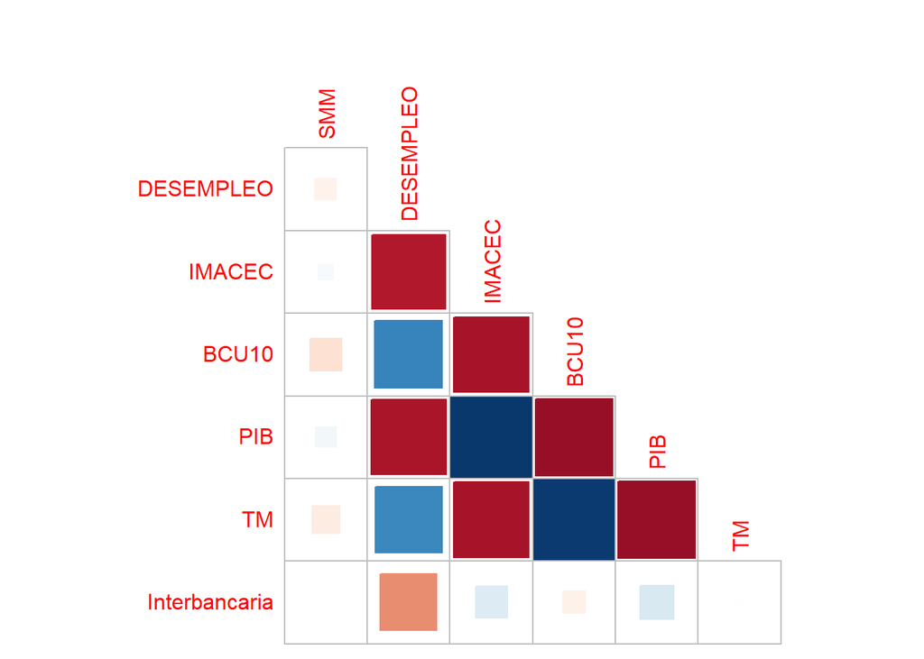

Nótese en primer lugar que existe poca correlación entre la variable objetivo (SMM) y las demás variables disponibles. En segundo lugar, es necesario poner atención a algunas correlaciones muy potentes entre regresores (como IMACEC y PIB), lo cual si bien es esperable tratándose de variables macroeconómicas, advierten sobre un posible problema de multicolinealidad entre ellas.

## Modelo lineal para SMM

```r
text_tbl <- data.frame(
Modelo = c("(1)", "(2)", "(3)",  "(4)", "(5)"),
Regresores = c(
"Todas las variables, incluyendo meses más intercepto",
"Desempleo, IMACEC, PIB, TM, Interbancaria, BCU10, Ene, Feb, Abr, May, Jul, Ago, Oct, Nov",
"Intercepto, TM, BCU10, Ene, Feb, Mar, Abr, May, Jun, Jul, Ago, Sep, Oct, Nov, Dic",
"Intercepto, TM, BCU10, ENE, ABR, MAY, JUL, AGO, OCT, NOV",
"Intercepto, PIB, TM, BCU10, ENE, FEB, ABR, MAY, JUL, AGO, OCT, NOV"
)
)
kable(text_tbl, "latex", booktabs = T, linesep = "\\addlinespace",
      caption = "Modelos lineales candidatos\\label{tab:tab_reg}"
      ) %>%
kable_styling(full_width = F) %>%
column_spec(1, bold = T, color = "red", width = "15mm") %>%
column_spec(2, width = "55mm")
```

| Modelo | Regresores |
| --- | --- |
| (1) | Todas las variables, incluyendo meses más intercepto |
| (2) | Desempleo, IMACEC, PIB, TM, Interbancaria, BCU10, Ene, Feb, Abr, May, Jul, Ago, Oct, Nov |
| (3) | Intercepto, TM, BCU10, Ene, Feb, Mar, Abr, May, Jun, Jul, Ago, Sep, Oct, Nov, Dic |
| (4) | Intercepto, TM, BCU10, ENE, ABR, MAY, JUL, AGO, OCT, NOV |
| (5) | Intercepto, PIB, TM, BCU10, ENE, FEB, ABR, MAY, JUL, AGO, OCT, NOV |

```r
fit01 = lm(SMM ~ ., data = DF)
datos01 = summary(fit01)

fit02 = lm(SMM ~ .-DIC-SEPT-JUN-MAR, data = DF)
datos02 = summary(fit02)

fit03 = lm(SMM ~ .-DESEMPLEO-IMACEC-PIB-Interbancaria, data = DF)
datos03 = summary(fit03)

fit04 = lm(SMM ~ 1 +TM +BCU10 +ENE +ABR +MAY +JUL +AGO +OCT +NOV, data = DF)
datos04 = summary(fit04)

step01 = stepAIC(fit01, direction = "backward", trace = FALSE)
d01 = summary(step01)

step02 = stepAIC(fit01, direction = "both", trace = FALSE)
d02 = summary(step02)

fit05 = lm(SMM ~ PIB + ENE + FEB + ABR + MAY + JUL + AGO + OCT + NOV + BCU10, data = DF)
d03 = summary(fit05)
```

| Modelo | R2 | R2aj | AIC | NS |
| --- | --- | --- | --- | --- |
| (1) | 0.39336 | 0.32551 | -1533.501 | 11/19 |
| (2) | 0.38897 | 0.33378 | -1538.276 | 5/15 |
| (3) | 0.37906 | 0.32732 | -1537.542 | 5/15 |
| (4) | 0.34989 | 0.31332 | -1537.737 | 0/10 |
| (5) | 0.38792 | 0.34531 | -1543.983 | 0/12 |

```r
vif(step01)
```

```
##     BCU10       PIB       ENE       FEB       ABR       MAY       JUL       AGO
## 11.649147  4.223602  1.159853  1.161208  1.151531  1.147876  1.148989  1.151663
##       OCT       NOV        TM
##  1.149068  1.148345 11.439297
```

```r
step01
```

```
##
## Call:
## lm(formula = SMM ~ BCU10 + PIB + ENE + FEB + ABR + MAY + JUL +
##     AGO + OCT + NOV + TM, data = DF)
##
## Coefficients:
## (Intercept)        BCU10          PIB          ENE          FEB          ABR
##   8.708e-03   -2.963e-03   -1.474e-07    5.435e-03    1.788e-03    3.225e-03
##         MAY          JUL          AGO          OCT          NOV           TM
##   2.328e-03    3.544e-03    2.356e-03    3.993e-03    3.496e-03    1.738e-01
```

## Modelo SARIMA para los residuos